# 1. Research identifying body features suitable for predicting hemoglobin levels

#### Sejeong Moon, 334004092

# 2. Introduction (10 pts)

### Background

> Hemoglobin (Hb) is the protein contained in red blood cells that is responsible for delivery of oxygen to the tissues. To ensure adequate tissue oxygenation, a sufficient hemoglobin level must be maintained. The amount of hemoglobin in whole blood is expressed in grams per deciliter (g/dl).

> When the hemoglobin level is low, the patient has anemia. Anemia is a condition that develops when your blood produces a lower-than-normal amount of healthy red blood cells. If you have anemia, your body does not get enough oxygen-rich blood. The lack of oxygen can make you feel tired or weak. You may also have shortness of breath, dizziness, headaches, or an irregular heartbeat.

### Goal

> Given the potential severe health implications which can be casued by low hemoglobin levels, individuals at a higher risk for anemia should be aware of it and seek medical advice. The objective of this research is to identify physical characteristics that may serve as predictors of hemoglobin levels. Predictions can suggest individuals at a higher risk for anemia take proactive measures to manage their hemoglobin level before severe illnesses arise.

### Objectives (research hypotheses)

> Hypothesis 1  
> **Older males have a higher possibility of low hemoglobin levels.**

> Hypothesis 2  
> **People who smoke and drink have a higher possibility of low hemoglobin levels.**

# 3. Data Description (15 pts)

> Data source **[Kaggel: Smoking and Drinking Dataset with body signal]** https://www.kaggle.com/datasets/sooyoungher/smoking-drinking-dataset/data  
> This dataset is collected from National Health Insurance Service in Korea.

#### Column description

- Sex (Nominal Categorical) : male, female
- age (Discrete Quantitative) : round up to 5 years
- SMK_stat_type_cd (Categorical) : Smoking state, 1(never), 2(used to smoke but quit), 3(still smoke)
- DRK_YN (Categorical) : Drinker(Y) or Not(N)
- hemoglobin (Continuous Quantitative) : hemoglobin level (g/dL)

## Data Preprocessing:

- Missing Values: No nan value
- Outliers: The rows with the hemoglobin level 1.0 have been considered as outliers and removed. Because the values in other columns were reasonable or within defined ranges (age 20 ~ 85, DRK_YN Y or N, SMK_stat_type_cd 1 ~ 3), no further process to find and remove outliers was proceeded.
- Duplicate rows: There were 26 duplicate rows out of 991346 rows. All duplicate rows have been removed. Because the number of duplicate rows is very small considering the size of dataset, it was expected that removing all duplicate rows would not have a negative impact on model predictions.
- Transform variables: Two clumns with object datatype (sex, DRK_YN) have been transfored to numerical datatype.

# 4. Methodology (25 pts)

## Model Evaluation and Selection (10 pts)

- Linear Regression  
  If there are linear relationships between dependent variable(hemoglobin) and independent variables, the linear regression model can predict hemoglobin quite well.
- Ridge and Lasso  
  If there is overfitting in a simple linear regression model, ridge and lasso can reduce the ovefitting by each regularization method. But this was not expected to perform better than the linear regression model, because there are only 4 columns, which is comparably small number, it is predicted that a simple linear regression model will not overfit the train set.
- Elastic Net  
  Since the elastic net is a model that combines Ridge and Lasso models, it is expected that Elastic net also will not be the best model if the ridge and lasso are not performing better than simple linear regression.

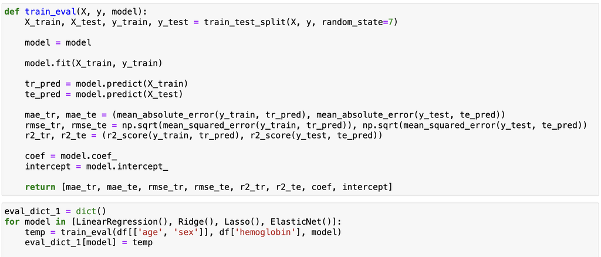

- Quantile regression  
  Quantile regression can be used when the conditions of linear regression are not satisfied (linearity, homoscedasticity, independence, or normality). If the linear regression cannot make a good prediction becuase the conditions are not met, quantile regression can perform better.

[figure not shown]

## Model Comparison (10 pts)

#### Evaluation metrics for hypothesis 1

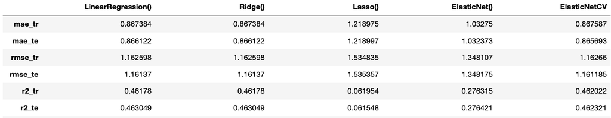

#### Evaluation metrics for hypothesis 2

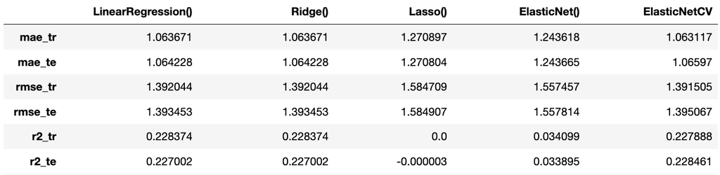

## Model Improvement (5 pts)

Elastic Net's performance also depends on the combining ratio of ridge and lasso, ElasticNetCV was used to find the best parameters.

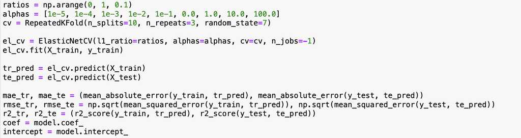

# 5. Results and Interpretation (15 pts)

For hypothesis 2 (People who smoke and drink have a higher possibility of low hemoglobin levels.), r2 score is 0.23 or lower. This means that hemoglobin is difficult to be predicted using smoking and drinking status.

# 6. Conclusion (10 pts)

Hypothesis 2 (People who smoke and drink have a higher possibility of low hemoglobin levels.) cannot be accepted, since the r2 score with the best model is lower than 0.3.

Although the model to test hypothesis 1 shows a certain linear relationship between age, sex and hemoglobin, but the relationship is not very high. Only 46% of the hemoglobin variance can be explained by the two variables. It means that there are more factors whihc affect hemoglobin. Other body features such as height and weight, body signals such as blood pressure, and related illnessed can be anaylzed with hemoglobin to find out more relationships and predict the hemoglobin better.

# 7. Reference and Appendix (5 pts)

### Reference

- https://www.kaggle.com/datasets/sooyoungher/smoking-drinking-dataset/data
- https://www.ncbi.nlm.nih.gov/pmc/articles/PMC6316192/#:~:text=In%20conclusion%2C%20we%20found%20a,of%20other%20clinical%20risk%20factors.
- https://health.kdca.go.kr/healthinfo/biz/health/gnrlzHealthInfo/gnrlzHealthInfo/gnrlzHealthInfoView.do?cntnts_sn=5292
- https://www.ncbi.nlm.nih.gov/books/NBK259/
- https://machinelearningmastery.com/chi-squared-test-for-machine-learning/
- https://www.ibm.com/docs/en/spss-statistics/saas?topic=model-pseudo-r-square
- https://www.nhlbi.nih.gov/health/anemia

### Python code

''' import pandas as pd import numpy as np import matplotlib.pyplot as plt import seaborn as sns

import warnings warnings.filterwarnings('ignore')

pd.set_option("display.max_rows", None) pd.set_option("display.max_columns", None)

data = pd.read_csv("smoking_driking_dataset.csv")

duplicate_rows = data[data.duplicated()] print("Dataset shape", data.shape, "number of duplicate rows: ", duplicate_rows.shape[0])

data = data.drop_duplicates() print("Dataset shape after removing duplicated rows", data.shape)

data = data[['sex', 'age', 'SMK_stat_type_cd', 'DRK_YN', 'hemoglobin']]

data.info()

data.describe()

outlier_rows = data[data['hemoglobin'] == 1] print("Dataset shape", data.shape, "number of outlier rows: ", outlier_rows.shape[0])

data = data.drop(index=outlier_rows.index) print("Dataset shape after removing outlier rows", data.shape)

data.isnull().sum()

print(data['sex'].value_counts(), '\n') print(data['DRK_YN'].value_counts(), '\n') print(data['SMK_stat_type_cd'].value_counts(), '\n') print('Age\n', data['age'].value_counts(), '\n')

from scipy.stats import chi2_contingency

data.describe()

data['hemoglobin_low'] = 0 data.head()

data.loc[(data['sex']=='Male') & (data['hemoglobin'] < 14), 'hemoglobin_low'] = 1 data.loc[(data['sex']=='Female') & (data['hemoglobin'] < 12), 'hemoglobin_low'] = 1

observed_data = pd.crosstab(data['sex'], data['hemoglobin_low'], margins = False)

alpha = 0.05

if p_value < alpha: print("There is a significant association between sex and hemoglobin.") else: print("There is no significant association between sex and hemoglobin.")

observed_data = pd.crosstab(data['age'], data['hemoglobin_low'], margins = False)

alpha = 0.05

if p_value < alpha: print("There is a significant association between age and hemoglobin.") else: print("There is no significant association between age and hemoglobin.")

observed_data = pd.crosstab(data['SMK_stat_type_cd'], data['hemoglobin_low'], margins = False)

alpha = 0.05

if p_value < alpha: print("There is a significant association between smoking and hemoglobin.") else: print("There is no significant association between smoking and hemoglobin.")

observed_data = pd.crosstab(data['DRK_YN'], data['hemoglobin_low'], margins = False)

alpha = 0.05

if p_value < alpha: print("There is a significant association between drinking and hemoglobin.") else: print("There is no significant association between drinking and hemoglobin.")

data.loc[data['sex']=='Male', 'sex'] = 1 # male: 1 data.loc[data['sex']=='Female', 'sex'] = -1 # Female: -1 data.loc[data['DRK_YN']=='N', 'DRK_YN'] = -1 # Not drinker: -1 data.loc[data['DRK_YN']=='Y', 'DRK_YN'] = 1 # Drinker: 1

data['SMK_stat_type_cd'] -= 2 # Never: -1, Used to smoke but quit: 0, Still smoke: 1

df = data.copy()

print('Sex\n', df['sex'].value_counts(), '\n') print('Drinking\n', df['DRK_YN'].value_counts(), '\n') print('Smoking\n', df['SMK_stat_type_cd'].value_counts(), '\n')

df.describe()

df.info()

corr_matrix = df.corr(numeric_only=False)

plt.figure(figsize=(5, 4)) sns.heatmap(corr_matrix, annot=True, cmap='coolwarm', linewidths=0.5) plt.title('Correlation Matrix') plt.show()

sample_row = np.random.randint(low=0, high=df.shape[0], size=10000) sample_df = df.iloc[sample_row, :]

plt.hist(sample_df['hemoglobin'], bins=50, color='pink', edgecolor='white') plt.xlabel('hemoglobin Value') plt.ylabel('Frequency') plt.title('hemoglobin') plt.grid(axis='y')

sns.scatterplot(data=sample_df, x='age', y='hemoglobin', hue='sex')

plt.title('Relationship between age, hemoglobin, and sex (Male:1, Female:-1)') plt.grid(axis='y')

plt.hist(sample_df['age'], bins=50, color='pink', edgecolor='white') plt.xlabel('age') plt.ylabel('Frequency') plt.title('Age') plt.grid(axis='y')

plt.hist(sample_df.loc[sample_df['sex']==1]['hemoglobin'], bins=50, color='pink', edgecolor='white') plt.xlabel('hemoglobin Value') plt.ylabel('Frequency') plt.title('hemoglobin') plt.grid(axis='y')

plt.hist(sample_df.loc[sample_df['sex']==-1]['hemoglobin'], bins=50, color='pink', edgecolor='white') plt.xlabel('hemoglobin Value') plt.ylabel('Frequency') plt.title('hemoglobin') plt.grid(axis='y')

sns.scatterplot(data=sample_df[sample_df['sex']==-1], x='age', y='hemoglobin', hue='DRK_YN')

plt.title('Relationship between age, hemoglobin, and drinking (male, drinker:1, non drinker:-1)') plt.grid(axis='y')

sns.scatterplot(data=sample_df[sample_df['sex']==-1], x='age', y='hemoglobin', hue='SMK_stat_type_cd')

plt.title('Relationship between age, hemoglobin, and smoking (male, smoking:1, quit:0, never:-1)') plt.grid(axis='y')

df = df.drop(columns=['hemoglobin_low'])

from sklearn.preprocessing import StandardScaler from sklearn.linear_model import LinearRegression, Ridge, Lasso, ElasticNet, ElasticNetCV from sklearn.model_selection import train_test_split, RepeatedKFold from sklearn.metrics import mean_squared_error, mean_absolute_error, r2_score

sample_row = np.random.randint(low=0, high=df.shape[0], size=10000) sample_df = df.iloc[sample_row, :]

def train_eval(X, y, model): X_train, X_test, y_train, y_test = train_test_split(X, y, random_state=7)

```
model = model

model.fit(X_train, y_train)

tr_pred = model.predict(X_train)
te_pred = model.predict(X_test)

mae_tr, mae_te = (mean_absolute_error(y_train, tr_pred), mean_absolute_error(y_test, te_pred))
rmse_tr, rmse_te = np.sqrt(mean_squared_error(y_train, tr_pred)), np.sqrt(mean_squared_error(y_test, te_pred))
r2_tr, r2_te = (r2_score(y_train, tr_pred), r2_score(y_test, te_pred))

coef = model.coef_
intercept = model.intercept_

return [mae_tr, mae_te, rmse_tr, rmse_te, r2_tr, r2_te, coef, intercept]
```

eval_dict_1 = dict() for model in [LinearRegression(), Ridge(), Lasso(), ElasticNet()]: temp = train_eval(df[['age', 'sex']], df['hemoglobin'], model) eval_dict_1[model] = temp

X_train, X_test, y_train, y_test = train_test_split(df[['age', 'sex']], df['hemoglobin']) ratios = np.arange(0, 1, 0.1) alphas = [1e-5, 1e-4, 1e-3, 1e-2, 1e-1, 0.0, 1.0, 10.0, 100.0] cv = RepeatedKFold(n_splits=10, n_repeats=3, random_state=7)

el_cv = ElasticNetCV(l1_ratio=ratios, alphas=alphas, cv=cv, n_jobs=-1) el_cv.fit(X_train, y_train)

tr_pred = el_cv.predict(X_train) te_pred = el_cv.predict(X_test)

eval_dict_1['ElasticNetCV'] = [mae_tr, mae_te, rmse_tr, rmse_te, r2_tr, r2_te, coef, intercept]

eval_dict_2 = dict()

X = df.loc[:, ['SMK_stat_type_cd', 'DRK_YN']] y = df.loc[:, ['hemoglobin']]

for model in [LinearRegression(), Ridge(), Lasso(), ElasticNet()]: temp = train_eval(X, y, model) eval_dict_2[model] = temp

X_train, X_test, y_train, y_test = train_test_split(df[['SMK_stat_type_cd', 'DRK_YN']], df['hemoglobin'])

el_cv = ElasticNetCV(l1_ratio=ratios, alphas=alphas, cv=cv, n_jobs=-1) el_cv.fit(X_train, y_train)

tr_pred = el_cv.predict(X_train) te_pred = el_cv.predict(X_test)

eval_dict_2['ElasticNetCV'] = [mae_tr, mae_te, rmse_tr, rmse_te, r2_tr, r2_te, coef, intercept]

evaluation_1 = pd.DataFrame(eval_dict_1, index=['mae_tr', 'mae_te', 'rmse_tr', 'rmse_te', 'r2_tr', 'r2_te', 'coef', 'intercept']) evaluation_1

evaluation_2 = pd.DataFrame(eval_dict_2, index=['mae_tr', 'mae_te', 'rmse_tr', 'rmse_te', 'r2_tr', 'r2_te', 'coef', 'intercept']) evaluation_2

line = pd.DataFrame({'x0':np.linspace(df['age'].max()+0.2, df['age'].min()-0.2, num=100)}) line['x1'] = np.linspace(df['sex'].max()+0.2, df['sex'].min()-0.2, num=100)

fig, axes = plt.subplots(1, 2, figsize=(10, 5), constrained_layout=True) fig.suptitle('Real hemoglobin and Prediction line (1: Male, -1:Female)', fontsize=20) features = ['age', 'sex']

for i in range(2): sns.scatterplot(data=sample_df, x=features[i], y='hemoglobin', hue='sex', ax=axes[i]) axes[i].plot(line['x'+str(i)], line['y'+str(i)], 'm-')

plt.show()

import statsmodels.formula.api as smf

quantiles = [0.2, 0.4, 0.6, 0.9] results = []

for q in quantiles: model = smf.quantreg('hemoglobin ~ sex + age', sample_df) result = model.fit(q=q) results.append(result)

for i, result in enumerate(results): print(f"\nQuantile: {quantiles[i]}") print(result.summary()) '''